# Real Estate Analysis

Mia Murphy

2023-10-01

This is an exploratory data analysis on a Kaggle data set. The data set is a real estate data set.

Some potential goals or objectives for an analytics project on this data set could be:

- Predicting the sale price of properties based on various features.
- Identifying which factors have the most significant influence on a property’s price.
- Analyzing the impact of neighborhood on property value.
- Evaluating the impact of renovations (`YearRemodAdd`) on sale price.
- Segmenting properties into various categories for targeted marketing or investment purposes.

#### Exploring the data set:

Before exploring data sets, making predictions is helpful. Not only do we get to see if we are accurate with our predictions, but it helps guide the investigative process. If I am a real estate agent, then I am going to be most interested in `SalePrice`. We can theorize that `SalePrice` is likely determined by the `OverallQual`, house size (`GrLivArea`) and `YearBuilt`. It will be interesting to see if there is a discernible difference between `YearBuilt` and `YearRemodAdd`.

For categorical, I will assume that `Neighborhood` is highly correlated with `SalePrice`. - Rarely are high value homes present in low value neighborhoods and vice versa. - There can be outliers, perhaps there is a wide variance in a college town or town with a long history.

Finding the highest correlation coefficient for numerical variables in relation to `SalePrice`.

```r
# A quick structure overview of the data
str(data[1:5])
```

```
## 'data.frame':    1460 obs. of  5 variables:
##  $ Id         : int  1 2 3 4 5 6 7 8 9 10 ...
##  $ MSSubClass : int  60 20 60 70 60 50 20 60 50 190 ...
##  $ MSZoning   : chr  "RL" "RL" "RL" "RL" ...
##  $ LotFrontage: int  65 80 68 60 84 85 75 NA 51 50 ...
##  $ LotArea    : int  8450 9600 11250 9550 14260 14115 10084 10382 6120 7420 ...
```

```r
# Remove the Id column as it's just an identifier and won't impact our analysis
df <- data %>% select(-Id)

# Check which numerical variable has the highest correlation with SalePrice
correlation_data <- df %>%
  correlate() %>%
  focus(SalePrice) %>%
  arrange(desc(SalePrice))

top_10_correlations <- head(correlation_data, 10)
print(top_10_correlations)
```

```
## # A tibble: 10 × 2
##    term         SalePrice
##    <chr>            <dbl>
##  1 OverallQual      0.791
##  2 GrLivArea        0.709
##  3 GarageCars       0.640
##  4 GarageArea       0.623
##  5 TotalBsmtSF      0.614
##  6 X1stFlrSF        0.606
##  7 FullBath         0.561
##  8 TotRmsAbvGrd     0.534
##  9 YearBuilt        0.523
## 10 YearRemodAdd     0.507
```

```r
# OverallQual has the highest correlation with SalePrice.
```

Here is another way to view the correlation data. This shows the data as a matrix, which will be visualized as a heat map.

```r
# Step 1: Filter only numeric or ordered factor columns
numeric_data <- df %>% select_if(~is.numeric(.) | is.ordered(.))

# Handle NAs
numeric_data[is.na(numeric_data)] <- 0

# Handle infinite values
numeric_data <- as.data.frame(lapply(numeric_data, function(col) {
  col[is.infinite(col)] <- 0
  return(col)
}))

# Compute correlations
cor_matrix <- rcorr(as.matrix(numeric_data))$r
```

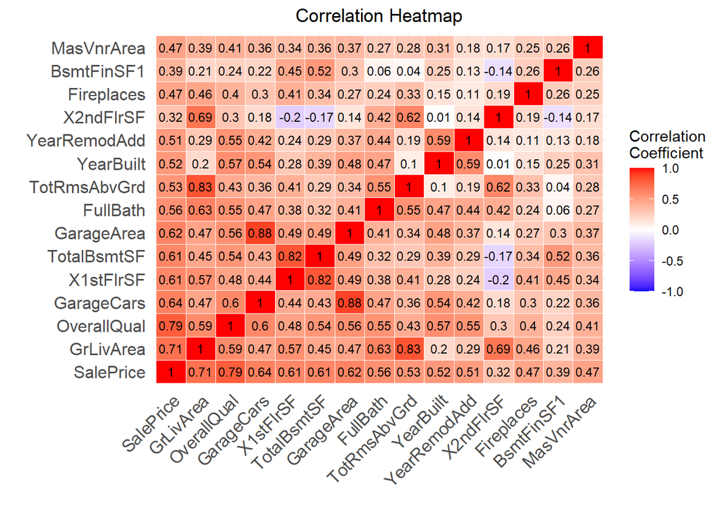

```r
# Compute average absolute correlation for each variable
avg_cor <- apply(cor_matrix, 1, function(row) mean(abs(row)))

# Sort variable names by their average absolute correlation
sorted_vars <- names(avg_cor)[order(avg_cor, decreasing = TRUE)]

# Select top n variables. For instance, n = 20.
top_vars <- sorted_vars[1:15]

# Subset the correlation matrix
subset_cor_matrix <- cor_matrix[top_vars, top_vars]

# Melt the matrix for ggplot2
melted_matrix <- melt(subset_cor_matrix)

ggplot(data = melted_matrix, aes(x = Var1, y = Var2)) +
  # Use geom_tile to create heatmap tiles
  geom_tile(aes(fill = value), color = "white") +

  # Label the cells with the correlation coefficients; adjust size for text
  geom_text(aes(label = round(value, 2)), size = 3, vjust = 0.5) +

  # Use a diverging color scale
  scale_fill_gradient2(low = "blue", high = "red", mid = "white",
                       midpoint = 0, limit = c(-1,1), space = "Lab",
                       name="Correlation\nCoefficient") +

  # Adjust theme settings for a cleaner look
  theme_minimal() +
  theme(
    axis.text.x = element_text(angle = 45, vjust = 1, size = 12, hjust = 1),
    axis.text.y = element_text(size = 12)
  ) +

  labs(x = "", y = "", title = "Correlation Heatmap") +

  # Center the title
  theme(plot.title = element_text(hjust = 0.5))
```

In this heatmap, we can easily identify variables that tend to move together (positive correlation) or in opposite directions (negative correlation). It provides a comprehensive overview of how the variables relate to each other, helping in identifying multicollinearity and understanding the relationships among different features in our dataset.

Using a scatterplot to visualize the OverallQual to SalePrice coefficient.

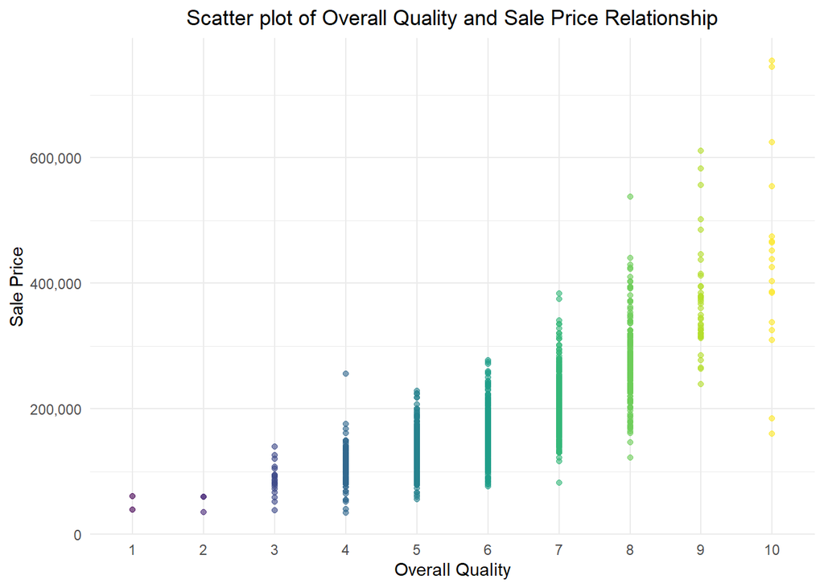

```r
# Convert OverallQual to a factor
data$OverallQual <- as.factor(data$OverallQual)

scatter_coef <- ggplot(data, aes(x = OverallQual, y = SalePrice)) +
  geom_point(aes(color = OverallQual), alpha = 0.6) +
  scale_color_viridis_d() +  # Use the discrete version of viridis
  scale_y_continuous(labels = comma) +  # Use the 'comma' formatter from the scales library
  labs(
    title = "Scatter plot of Overall Quality and Sale Price Relationship",
    x = "Overall Quality",
    y = "Sale Price"
  ) +
  theme_minimal() +
  theme(legend.position = "none",  # Remove the legend
        plot.title = element_text(hjust = 0.5))  # Center the title

print(scatter_coef)
```

- Strength & Direction: 0.791 indicates a strong positive linear relationship. This suggests that as `OverallQual` (Overall Quality) increases, `SalePrice` generally also increases. This relationship is viewable in the above image.
- Outliers: Outliers can influence the correlation coefficient. Even if a relationship is strong, a few outliers can decrease (or increase) the correlation.

From this visual, we can see quite a few outliers.

#### Categorical variables

Before I dive into the outliers, I want to check out the categorical variables by including them in our correlation coefficient output. This requires a bit more work by using dummy variables, which the package `fastDummies` can handle efficiently.

```r
dummy_data <- dummy_cols(df)
```

```r
# Filter only numeric columns
numeric_dummy_data <- dummy_data %>% select_if(is.numeric)

# Filter only columns with no NA values
complete_cols_2 <- numeric_dummy_data[, !apply(is.na(numeric_dummy_data), 2, any)]

# Compute the correlation matrix
cor_matrix_2 <- cor(complete_cols_2)

# Extract the 'SalePrice' column
saleprice_correlations_2 <- cor_matrix_2[,"SalePrice"]

# Remove the correlation of SalePrice with itself
saleprice_correlations_2 <- saleprice_correlations_2[-which(names(saleprice_correlations_2) == "SalePrice")]

# Rank the correlations
ranked_correlations_2 <- sort(saleprice_correlations_2, decreasing=TRUE)
```

Now that we have prepared the dummy data, we can visualize the top 10 and bottom 10 correlation coefficients.

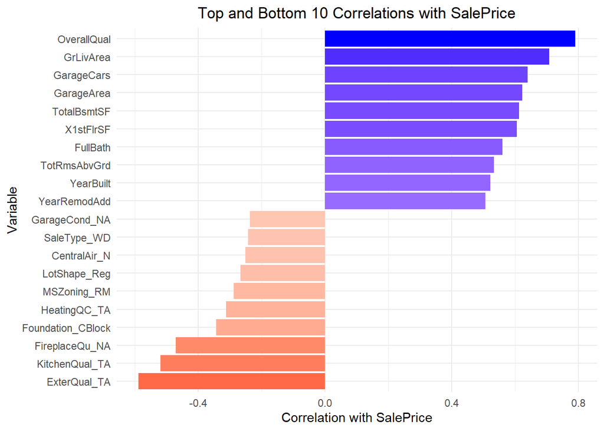

```r
# Extract the top 10 and bottom 10 correlations
top_10 <- head(ranked_correlations_2, 10)
bottom_10 <- tail(ranked_correlations_2, 10)

# Combine them into a single dataframe
combined <- data.frame(Variable = c(names(top_10), names(bottom_10)),
                       Correlation = c(top_10, bottom_10))


correlation_plot <- ggplot(combined, aes(x = reorder(Variable, Correlation), y = Correlation, fill = Correlation)) +
  geom_bar(stat="identity") +
  coord_flip() + # Flip the axes for a horizontal bar plot
  labs(title = "Top and Bottom 10 Correlations with SalePrice",
       x = "Variable",
       y = "Correlation with SalePrice") +
  theme_minimal() +
  theme(
    plot.title = element_text(hjust = 0.5),  # Center the title
    legend.position = "none"                 # Remove the legend
  ) +
  scale_fill_gradient2(midpoint = 0, low = "red", mid = "white", high = "blue",
                       guide = FALSE) # Gradient fill based on correlation value

print(correlation_plot)
```

We see that there are no categorical variables in the top ten (if we include more than ten, eventually we will see certain Neighborhoods pop up), but as we should expect, having no central air is near the bottom.

Here is what the Neighborhood vs SalePrice correlation coefficient looks like.

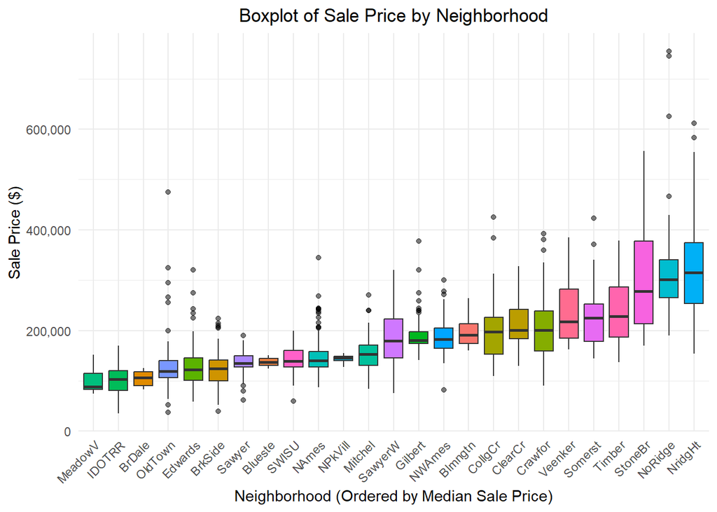

```r
# Visualize the SalePrice across different Neighborhoods using a boxplot
# Theory: Neighborhood strongly determines SalePrice
# Preparing the data by computing the order of neighborhoods based on their median SalePrice
neighborhood_order <- data %>%
  group_by(Neighborhood) %>%
  summarise(median_price = median(SalePrice, na.rm = TRUE)) %>%
  arrange(median_price) %>%
  pull(Neighborhood)

boxplot_chart_with_outliers <- ggplot(data, aes(x = factor(Neighborhood, levels = neighborhood_order), y = SalePrice)) +
  geom_boxplot(aes(fill = Neighborhood), outlier.alpha = 0.5, outlier.color = "black", outlier.size = 1.5) +
  theme_minimal() +
  theme(
    axis.text.x = element_text(angle = 45, hjust = 1, vjust = 1),
    legend.position = "none", # Remove legend for color fill since it's redundant
    plot.title = element_text(hjust = 0.5)
  ) +
  scale_y_continuous(labels = scales::comma) +  # Format y-axis with comma separators
  labs(
    title = "Boxplot of Sale Price by Neighborhood",
    x = "Neighborhood (Ordered by Median Sale Price)",
    y = "Sale Price ($)"
  )

print(boxplot_chart_with_outliers)
```

#### Checking the number of outliers (SalePrice)

To find the outliers, we use `quantile` to find Q1 and Q3. IQR is Q3 - Q1, as seen below.

```r
# Calculate Q1, Q3, and IQR
Q1 <- quantile(data$SalePrice, 0.25)
Q3 <- quantile(data$SalePrice, 0.75)
IQR <- Q3 - Q1

# Determine outliers
outliers <- data$SalePrice[data$SalePrice < (Q1 - 1.5 * IQR) | data$SalePrice > (Q3 + 1.5 * IQR)]

# Print the total number of outliers
total_outliers <- length(outliers)
print(total_outliers)
```

```
## [1] 61
```

Visualizing SalePrice and YearBuilt.

We should see that as homes are built later (newer homes), SalePrice increases.

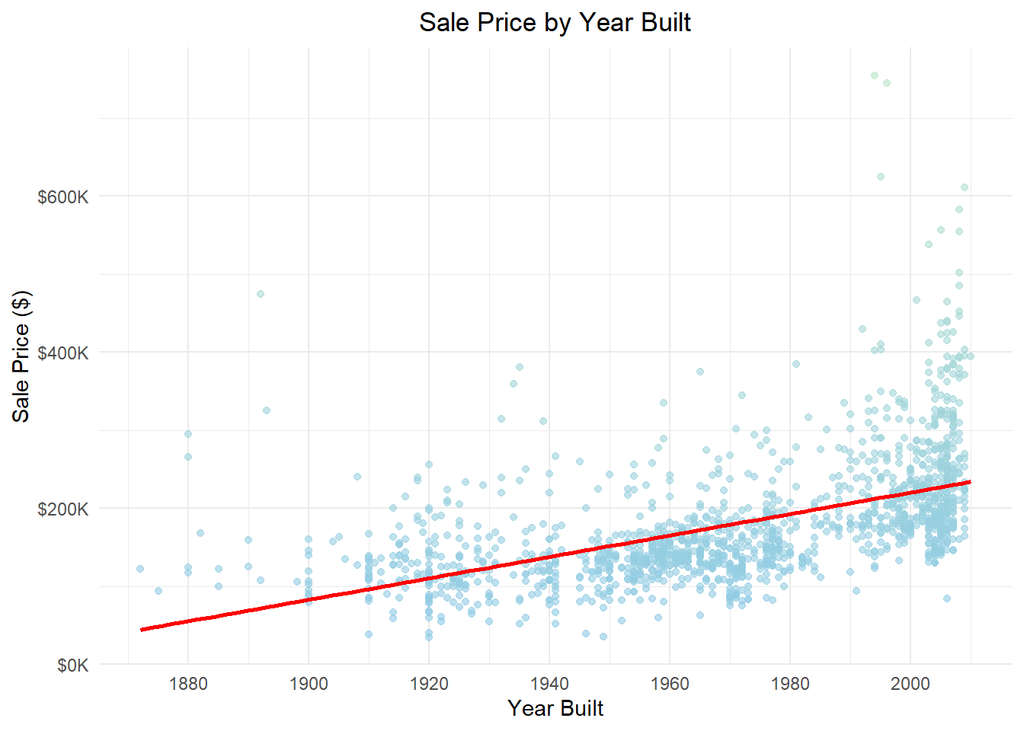

```r
ggplot(data, aes(x = YearBuilt, y = SalePrice)) +
  geom_point(aes(color = SalePrice), alpha = 0.6) +
  scale_color_gradient(
    name = "Sale Price ($)",
    low = "#8ecae6",  # Pastel neon blue
    high = "#b7e4c7", # Bright pastel green
    labels = scales::dollar_format(suffix = "K", scale = 1e-3),
    breaks = c(50000, 150000, 250000, 350000, 450000)
  ) +
  geom_smooth(method = "lm", se = FALSE, color = "red") +
  labs(
    title = "Sale Price by Year Built",
    x = "Year Built",
    y = "Sale Price ($)"
  ) +
  scale_y_continuous(labels = scales::dollar_format(suffix = "K", scale = 1e-3)) +
  scale_x_continuous(breaks = seq(1880, 2020, by = 20)) +
  theme_minimal() +
  theme(
    plot.title = element_text(hjust = 0.5),
    legend.position = "none")
```

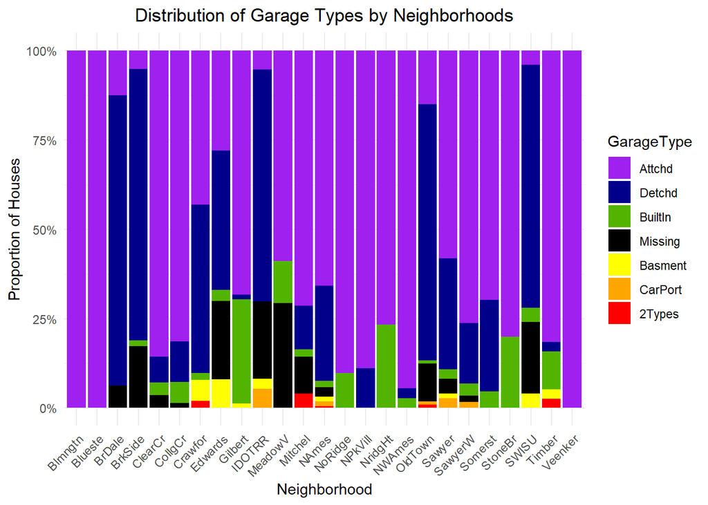

```r
# Analyze categorical variables,
# specifically looking at the relationship between GarageType and Neighborhood

# Preparing the data by calculating the proportion of each GarageType within each Neighborhood
garage_order <- data %>%
  group_by(Neighborhood, GarageType) %>%
  dplyr::summarize(Count = n()) %>%
  mutate(Total = sum(Count),
         Proportion = Count / Total) %>%
  arrange(Neighborhood, Proportion) %>%
  pull(GarageType)

garage_order <- unique(garage_order)

filtered_data <- data
filtered_data$GarageType <- factor(filtered_data$GarageType, levels = garage_order)
filtered_data$GarageType <- factor(ifelse(is.na(filtered_data$GarageType), "Missing",
                                          as.character(filtered_data$GarageType)))

freq_order <- sort(table(filtered_data$GarageType), decreasing = TRUE)
filtered_data$GarageType <- factor(filtered_data$GarageType, levels = names(freq_order))

default_colors <- scales::hue_pal()(length(levels(filtered_data$GarageType)))
names(default_colors) <- levels(filtered_data$GarageType)

# Override specific colors
default_colors["2Types"] <- "red"
default_colors["Attchd"] <- "purple"
default_colors["Basment"] <- "yellow"
default_colors["Detchd"] <- "darkblue"
default_colors["Missing"] <- "black"
default_colors["CarPort"] <- "orange"

stacked_chart <- ggplot(data = filtered_data, aes(x = Neighborhood, fill = GarageType)) +
  geom_bar(position = "fill") +
  labs(title = "Distribution of Garage Types by Neighborhoods",
       x = "Neighborhood",
       y = "Proportion of Houses") +
  scale_y_continuous(labels = scales::percent) +
  scale_fill_manual(values = default_colors) +
  theme_minimal() +
  theme(axis.text.x = element_text(angle = 45, hjust = 1),
        plot.title = element_text(hjust = 0.5))  # Center the title

print(stacked_chart)
```

```r
# Checking proportions
percentage_data <- data %>%
  group_by(Neighborhood, GarageType) %>%
  tally() %>%
  group_by(Neighborhood) %>%
  mutate(Total = sum(n),
         Percentage = n / Total * 100) %>%
  select(Neighborhood, GarageType, n, Percentage) %>%  # Including the 'n' column here
  arrange(Neighborhood, -Percentage)

print(percentage_data)
```

```
## # A tibble: 93 × 4
## # Groups:   Neighborhood [25]
##    Neighborhood GarageType     n Percentage
##    <chr>        <chr>      <int>      <dbl>
##  1 Blmngtn      Attchd        17     100
##  2 Blueste      Attchd         2     100
##  3 BrDale       Detchd        13      81.2
##  4 BrDale       Attchd         2      12.5
##  5 BrDale       <NA>           1       6.25
##  6 BrkSide      Detchd        44      75.9
##  7 BrkSide      <NA>          10      17.2
##  8 BrkSide      Attchd         3       5.17
##  9 BrkSide      BuiltIn        1       1.72
## 10 ClearCr      Attchd        24      85.7
## # ℹ 83 more rows
```

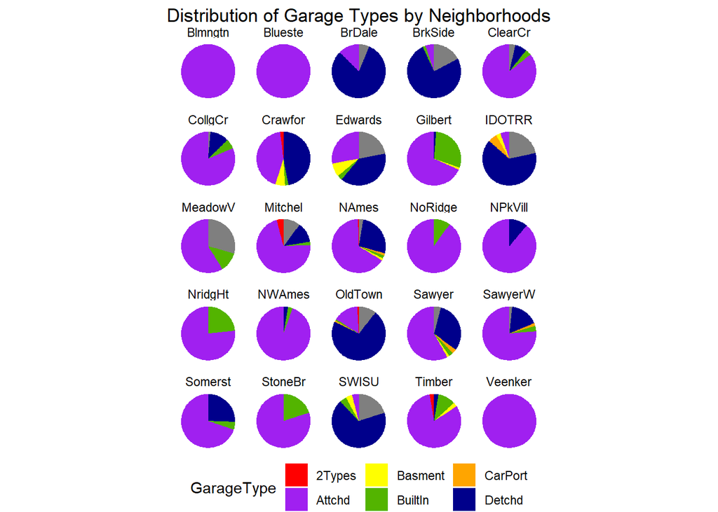

```r
# Trying a second data visualization
percentage_data <- data %>%
  group_by(Neighborhood, GarageType) %>%
  tally() %>%
  group_by(Neighborhood) %>%
  mutate(Total = sum(n),
         Percentage = n / Total) %>%
  ungroup()

# Plotting as a pie chart
ggplot(percentage_data, aes(x = "", y = Percentage, fill = GarageType)) +
  geom_bar(stat="identity", width=1) +
  coord_polar(theta="y") +
  facet_wrap(~Neighborhood) +
  labs(title = "Distribution of Garage Types by Neighborhoods",
       x = NULL,
       y = NULL) +
  scale_fill_manual(values = default_colors) +
  theme_void() +
  theme(legend.position = "bottom",
        plot.title = element_text(hjust = 0.5))  # Adjust the title position
```

OldTown has mostly detached garages. This is interesting since as the name implies, there are a lot of old houses here, so we might delve into the history of OldTown. This project will continue as a separate analysis, specifically on OldTown.